# Ako vytvoriť reprezentatívny obrázok lineárnej regresie

Samuel Hudec

18 októbra 2018

Dôležitou súčasťou každého štatistika alebo človeka pracujúceho v oblasti dátovej analýzi je spísanie **záverečného reportu** *(prezentácie)*. Okrem číselných výstupov z regresie *(odhady, konfidenčné intervaly a pod.)* je veľmi dôležité výsledok reprezentovať **vhodným obrázkom**.

U viacerých ľudí som si všimol isté pochybenia pri tvorení prezentačných obrázkov. Malé nedostatky dokážu celkovo pokaziť dojem z inak výborne odvedenej práce. Týmto príspevkom by som rád poukázal na základy, ktoré je potrebné vykonať pri tvorení takéhoto obrázku.

Vhodným balíčkom na vytváranie grafickej vizualizácie je `ggplot2`. Pravidelné aktualizácie robia z balíčka kvalitný a nestarnúci nástroj na profesionálnu vizualizáciu. Nasledujúce kroky budú zamerané výhradne na tento balíček.

## Regresný model

Pre ilustráciu si vezmime dáta `teengamb` z knižnice `faraway` a fitnime regresný model.

```
##
## Call:
## lm(formula = gamble ~ sex + income + status, data = teengamb)
##
## Residuals:
##     Min      1Q  Median      3Q     Max
## -48.682 -12.169  -0.268   9.161  97.728
##
## Coefficients:
##             Estimate Std. Error t value Pr(>|t|)
## (Intercept)  13.0315    15.8676   0.821  0.41603
## sex1        -24.3393     8.1274  -2.995  0.00454 **
## income        4.9280     1.0352   4.760 2.21e-05 ***
## status       -0.1496     0.2413  -0.620  0.53856
## ---
## Signif. codes:  0 '***' 0.001 '**' 0.01 '*' 0.05 '.' 0.1 ' ' 1
##
## Residual standard error: 22.92 on 43 degrees of freedom
## Multiple R-squared:  0.5058, Adjusted R-squared:  0.4713
## F-statistic: 14.67 on 3 and 43 DF,  p-value: 1.014e-06
```

Poznámka: *V tomto texte sa nebudem zaoberať vhodnosťou modelu, signifikanciu a pod.*

## Reprezentatívny obrázok regresného modelu

Máme za úlohu ukázať ako súvisí pohlavie, príjem a socio-ekonomický status na gambling mladých vo Veľkej Británii.

#### Voľba vhodného prediktora

Prvý krok pri viacrozmernej regresie je správne si zvoliť prediktor ku odozve. Obrázok sa kreslí hlavne podľa toho, čo sa vám zdá najzaujímavejšie. Pozrime sa, čo máme k dizpozícii my:

- **pohlavie** - binárna premenná sa na reprezentovanie fakt nehodí *(aj keď som sa už stretol aj stým lol)*
- **príjem** - reálna premenná a veľmi vhodná na použitie, ešte k tomu vzhľadom na význam sa príjem často používa *(lebo peniaze zaujímajú každého)*
- **socio-ekonomický status** - celočíselná premenná, taktiež vhodná, ak nadobúda “veľa” hodnôd *(v našom prípade len 10)*

Začnime od začiatku a nakreslime si prvý náčrt zatiaľ bez regresie.

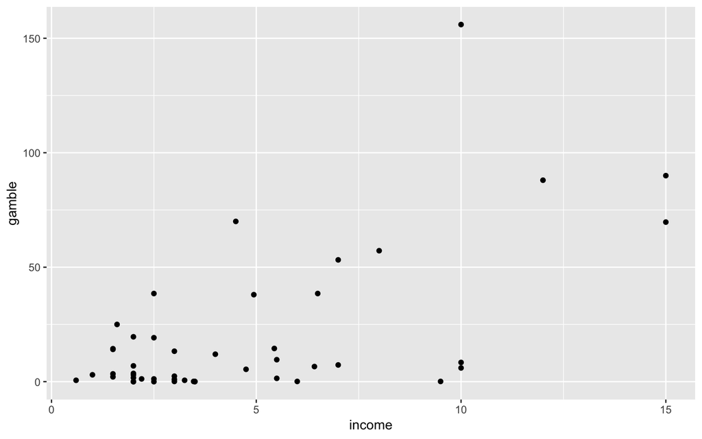

```r
ggplot(data = teengamb, mapping = aes(y = gamble, x = income)) +
  geom_point()
```

#### Zakomponovanie prediktorov pomocou bodov.

Body na obrázku sú nevýrazné a niektoré sa dokonca prekrývajú. Všeobecne body môžeme od seba navzájom odlíšiť podľa **farby**, **tvaru**, **jasu** a **veľkosti**.

V našom modely sa nachádza binárna *(faktorová)* premenná pohlavie vhodná na zakomponovanie. V prípade faktorovej premennej je zaužívané odlišovať body podľa **farby**, ale je to vec názoru a estetiky. V našom prípade odlíšenie podľa farby maximálne vyhovuje. Najvhodnejšie je si už na začiatku farby zafixovať.

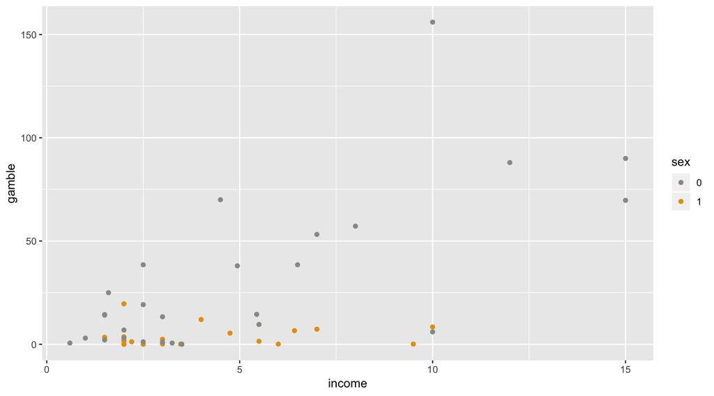

```r
ggplot(data = teengamb, mapping = aes(y = gamble, x = income, col = sex)) +
  geom_point() +
  scale_colour_manual(values = c("#999999", "#E69F00"))
```

Teraz obrázok nesie nielen informáciu o príjme, ale aj jasne odlišuje pohlavia.

Model obsahuje ešte jednu zaujímavú celočíselnú premennú socio-ekonomický status. Kedže je táto premenná usporiadaná, môžeme na dlíšenie použiť **veľkosť** bodu.

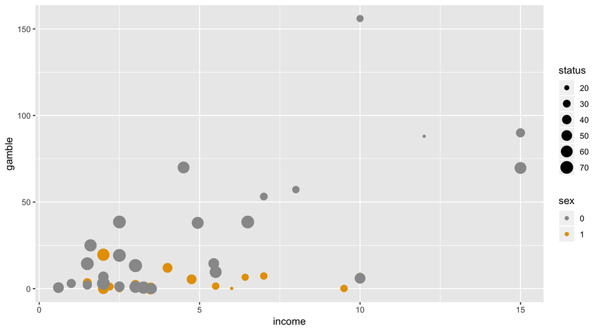

```r
ggplot(data = teengamb, mapping = aes(y = gamble, x = income, col = sex, size = status)) +
  geom_point() +
  scale_colour_manual(values = c("#999999", "#E69F00"))
```

V tomto štátiu úpravy bodu musíme skončiť aj keby máme k dispozícii viacej premenných, akékoľvek pridanie rôzneho tvaru alebo jasu by už bolo “pretečenie kotla”. Samozrejme závisí od modelu a okolnosti. Nakoniec, prekrívanie bodov ošetrime zníženim **jasu**.

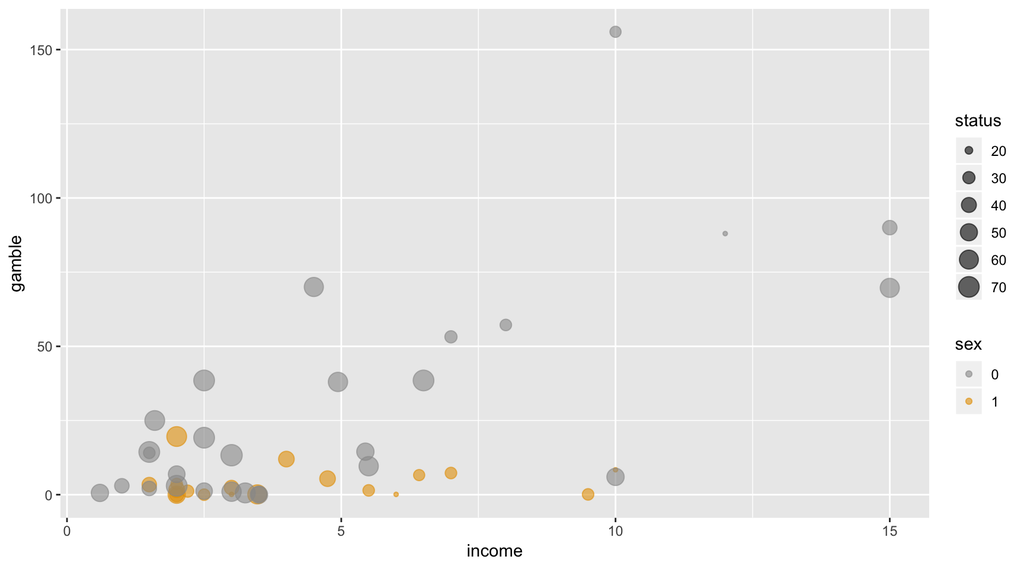

```r
ggplot(data = teengamb, mapping = aes(y = gamble, x = income, col = sex, size = status)) +
  geom_point(alpha = 0.6) +
  scale_colour_manual(values = c("#999999", "#E69F00"))
```

#### Popis

Veľmi podceňovaná časť u mnohých, pričom týmto “detailom” môžete veľmi pokaziť celkový dojem z prezentovaného výsleku. Osi treba **vždy** jednoznačne a čo najkratšie pomenovať, ideálne je pridať aj mieru.

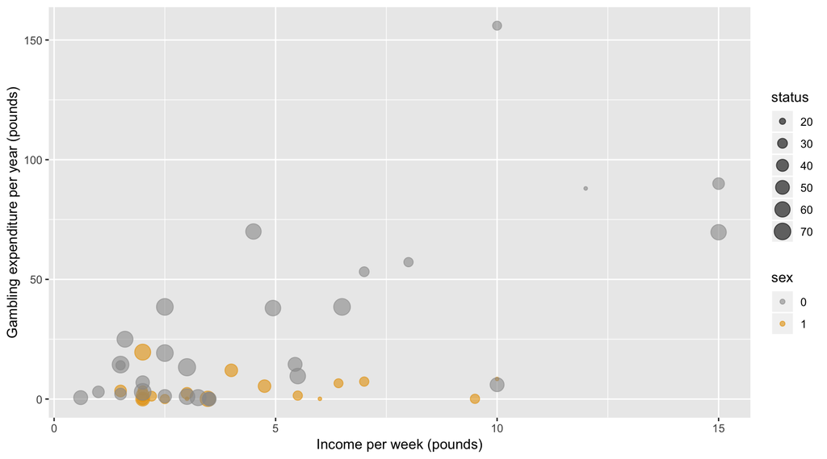

```r
ggplot(data = teengamb, mapping = aes(y = gamble, x = income, col = sex, size = status)) +
  geom_point(alpha = 0.6) +
  scale_colour_manual(values = c("#999999", "#E69F00")) +
  labs(y = "Gambling expenditure per year (pounds)",
    x = "Income per week (pounds)")
```

Tak isto aj legendu.

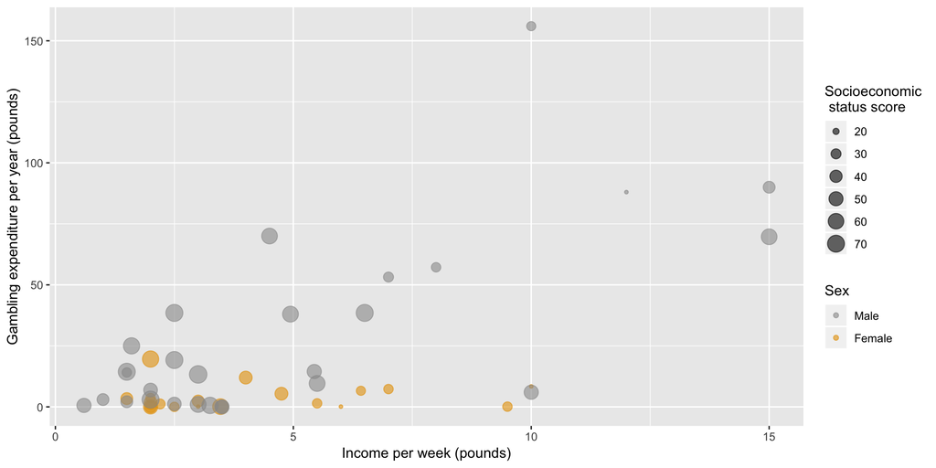

```r
ggplot(data = teengamb, mapping = aes(y = gamble, x = income, col = sex, size = status)) +
  geom_point(alpha = 0.6) +
  scale_colour_manual(values = c("#999999", "#E69F00"),
    name="Sex",
    breaks=c("0","1"),
    labels=c("Male", "Female")) +
  labs(y = "Gambling expenditure per year (pounds)",
    x = "Income per week (pounds)",
    size = "Socioeconomic\n status score")
```

Nakoniec sa môžete pohrať aj s nastavením veľkosti písma a podobne, tu nepôjdeme až tak do detailu.

#### Znázornenie regresie

Vzhľdom na faktorovú premennú si náš obrázok vyžaduje vložiť dve priamky, zvlášť pre mužov a pre ženy. Pričom šikovne využijeme zafixovaných farieb a ofarbíme priamky rovnakými farbami ako body, takto **nie je potrebné** priamky zvlášť pomenovať.

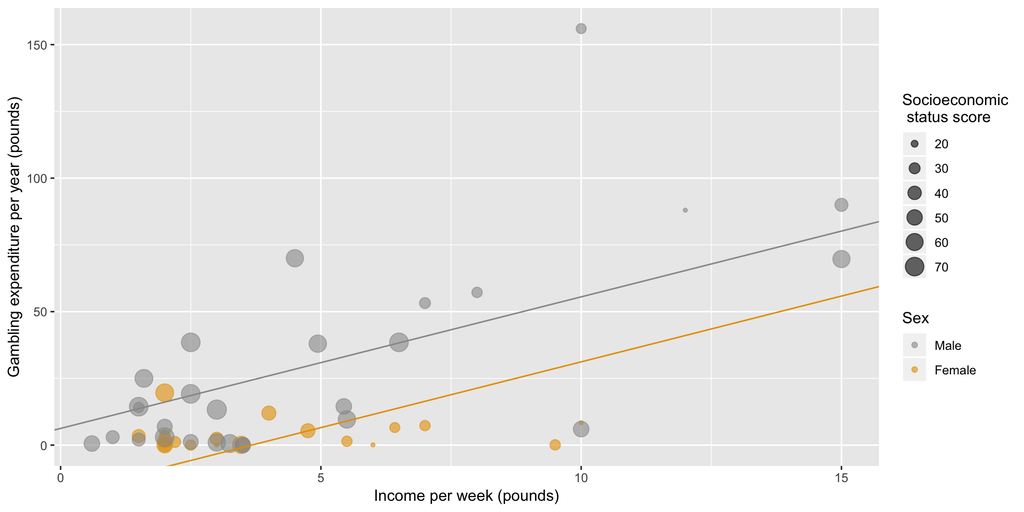

```r
ggplot(data = teengamb, mapping = aes(y = gamble, x = income, col = sex, size = status)) +
  geom_point(alpha = 0.6) +
  scale_colour_manual(values = c("#999999", "#E69F00"),
    name="Sex",
    breaks=c("0","1"),
    labels=c("Male", "Female")) +
  labs(y = "Gambling expenditure per year (pounds)",
    x = "Income per week (pounds)",
    size = "Socioeconomic\n status score") +
  geom_abline(intercept = (13.0315 - 0.1496*mean(teengamb$status)),
    slope = 4.9280,
    col="#999999") +
  geom_abline(intercept = (13.0315 - 24.3393 - 0.1496*mean(teengamb$status)),
    slope = 4.9280,
    col="#E69F00")
```

#### Zmena témy (volitelné)

Nakoniec, sivý podklad grafu v interakcii so znížením jasom bodov môže pôsobiť rušivo na bielom podklade *(pre niekoho)*. Knižnica obsahuje celú škálu tém, kde jednoduchým príkazom zmeníte vzhľad dramaticky závisí od estetiky. Napríklad mne sa páči `theme_minimal()` :)

```r
ggplot(data = teengamb, mapping = aes(y = gamble, x = income, col = sex, size = status)) +
  geom_point(alpha = 0.6) +
  scale_colour_manual(values = c("#999999", "#E69F00"),
    name="Sex",
    breaks=c("0","1"),
    labels=c("Male", "Female")) +
  labs(y = "Gambling expenditure per year (pounds)",
    x = "Income per week (pounds)",
    size = "Socioeconomic\n status score") +
  geom_abline(intercept = (13.0315 - 0.1496*mean(teengamb$status)),
    slope = 4.9280,
    col="#999999") +
  geom_abline(intercept = (13.0315 - 24.3393 - 0.1496*mean(teengamb$status)),
    slope = 4.9280,
    col="#E69F00") +
  theme_minimal()
```

[output not shown]

## Celkový význam obrázku

Takto zostavený obrázok nám dáva rozšírenú informáciu o vplyve príjmov, socio-ekonomickom statuse a pohlaví na gamblovanie vo Veľkej Británii. Obrázkom ľahko odprezentujeme:

[figure not shown]

Vhodne zostavený obrázok len povedal **to isté čo najdete vo výpise z regresie.**